# Project: Investigate a Dataset - TMDb Movie Data

- Introduction
- Data Wrangling
- Exploratory Data Analysis
- Conclusions
- Limitations

## Introduction

### Dataset Description

The dataset used in this project is the TMDb Movies Dataset, which contains information about approximately 10,000 movies collected from The Movie Database (TMDb). The dataset provides detailed information about movies including their financial performance, popularity, ratings, production details, and release information.

Each row in the dataset represents a single movie, while each column represents a specific attribute related to that movie.

#### Columns Description

**id**: Unique identifier for each movie

**imdb_id**: Unique movie identifier from IMDb

**popularity**: Popularity score based on user engagement and views

**budget**: Estimated production budget of the movie

**revenue**: Total revenue generated by the movie

**original_title**: Original title of the movie

**cast**: List of actors involved in the movie

**homepage**: Official website of the movie

**director**: Director of the movie

**tagline**: Promotional tagline of the movie

**keywords**: Keywords describing the movie content

**overview**: Brief summary of the movie plot

**runtime**: Duration of the movie in minutes

**genres**: Movie genres separated by a pipe (|) symbol

**production_companies**: Production companies involved in the movie

**release_date**: The date the movie was released

**vote_count**: Number of user votes received

**vote_average**: Average user rating score

**release_year**: Year the movie was released

**budget_adj**: Budget adjusted for inflation (in 2010 dollars)

**revenue_adj**: Revenue adjusted for inflation (in 2010 dollars)

### Question(s) for Analysis

#### Main Question:

- What factors are associated with higher movie revenue?

#### Supported Questions:

1. Is there a relationship between movie budget and revenue?
2. Do certain movie genres generate higher revenue than others?
3. Does movie popularity influence revenue?
4. Is there a relationship between audience ratings and movie revenue?

In this investigation, revenue will be treated as the **dependent variable**, while budget, genres, popularity, and vote_average will be treated as **independent variables**.

```python
import pandas as pd
import numpy as np
import matplotlib.pyplot as plt
import seaborn as sns

%matplotlib inline
```

## Data Wrangling

### General Properties

```python
# Load dataset
df = pd.read_csv('Database_TMDb_movie_data/tmdb-movies.csv')

# Display first few rows
print("Display first few rows")
print("===========================================")
df.head()
```

```
Display first few rows
===========================================
```

|  | id | imdb_id | popularity | budget | revenue | original_title | cast | homepage | director | tagline | ... | overview | runtime | genres | production_companies | release_date | vote_count | vote_average | release_year | budget_adj | revenue_adj |
| --- | --- | --- | --- | --- | --- | --- | --- | --- | --- | --- | --- | --- | --- | --- | --- | --- | --- | --- | --- | --- | --- |
| 0 | 135397 | tt0369610 | 32.985763 | 150000000 | 1513528810 | Jurassic World | Chris Pratt\|Bryce Dallas Howard\|Irrfan Khan\|Vi... | http://www.jurassicworld.com/ | Colin Trevorrow | The park is open. | ... | Twenty-two years after the events of Jurassic ... | 124 | Action\|Adventure\|Science Fiction\|Thriller | Universal Studios\|Amblin Entertainment\|Legenda... | 6/9/15 | 5562 | 6.5 | 2015 | 1.379999e+08 | 1.392446e+09 |
| 1 | 76341 | tt1392190 | 28.419936 | 150000000 | 378436354 | Mad Max: Fury Road | Tom Hardy\|Charlize Theron\|Hugh Keays-Byrne\|Nic... | http://www.madmaxmovie.com/ | George Miller | What a Lovely Day. | ... | An apocalyptic story set in the furthest reach... | 120 | Action\|Adventure\|Science Fiction\|Thriller | Village Roadshow Pictures\|Kennedy Miller Produ... | 5/13/15 | 6185 | 7.1 | 2015 | 1.379999e+08 | 3.481613e+08 |
| 2 | 262500 | tt2908446 | 13.112507 | 110000000 | 295238201 | Insurgent | Shailene Woodley\|Theo James\|Kate Winslet\|Ansel... | http://www.thedivergentseries.movie/#insurgent | Robert Schwentke | One Choice Can Destroy You | ... | Beatrice Prior must confront her inner demons ... | 119 | Adventure\|Science Fiction\|Thriller | Summit Entertainment\|Mandeville Films\|Red Wago... | 3/18/15 | 2480 | 6.3 | 2015 | 1.012000e+08 | 2.716190e+08 |
| 3 | 140607 | tt2488496 | 11.173104 | 200000000 | 2068178225 | Star Wars: The Force Awakens | Harrison Ford\|Mark Hamill\|Carrie Fisher\|Adam D... | http://www.starwars.com/films/star-wars-episod... | J.J. Abrams | Every generation has a story. | ... | Thirty years after defeating the Galactic Empi... | 136 | Action\|Adventure\|Science Fiction\|Fantasy | Lucasfilm\|Truenorth Productions\|Bad Robot | 12/15/15 | 5292 | 7.5 | 2015 | 1.839999e+08 | 1.902723e+09 |
| 4 | 168259 | tt2820852 | 9.335014 | 190000000 | 1506249360 | Furious 7 | Vin Diesel\|Paul Walker\|Jason Statham\|Michelle ... | http://www.furious7.com/ | James Wan | Vengeance Hits Home | ... | Deckard Shaw seeks revenge against Dominic Tor... | 137 | Action\|Crime\|Thriller | Universal Pictures\|Original Film\|Media Rights ... | 4/1/15 | 2947 | 7.3 | 2015 | 1.747999e+08 | 1.385749e+09 |

5 rows × 21 columns

```python
# Check dataframe size
print("Check dataframe size")
print("===========================================")
df.shape
```

```
Check dataframe size
===========================================
```

```
(10866, 21)
```

```python
# Inspect data types and missing values
print("Inspect data types and missing values")
print("===========================================")
df.info()
```

```
Inspect data types and missing values
===========================================
<class 'pandas.core.frame.DataFrame'>
RangeIndex: 10866 entries, 0 to 10865
Data columns (total 21 columns):
 #   Column                Non-Null Count  Dtype
---  ------                --------------  -----
 0   id                    10866 non-null  int64
 1   imdb_id               10856 non-null  object
 2   popularity            10866 non-null  float64
 3   budget                10866 non-null  int64
 4   revenue               10866 non-null  int64
 5   original_title        10866 non-null  object
 6   cast                  10790 non-null  object
 7   homepage              2936 non-null   object
 8   director              10822 non-null  object
 9   tagline               8042 non-null   object
 10  keywords              9373 non-null   object
 11  overview              10862 non-null  object
 12  runtime               10866 non-null  int64
 13  genres                10843 non-null  object
 14  production_companies  9836 non-null   object
 15  release_date          10866 non-null  object
 16  vote_count            10866 non-null  int64
 17  vote_average          10866 non-null  float64
 18  release_year          10866 non-null  int64
 19  budget_adj            10866 non-null  float64
 20  revenue_adj           10866 non-null  float64
dtypes: float64(4), int64(6), object(11)
memory usage: 1.7+ MB
```

```python
# Summary statistics
print("Summary statistics")
print("===========================================")
df.describe()
```

```
Summary statistics
===========================================
```

|  | id | popularity | budget | revenue | runtime | vote_count | vote_average | release_year | budget_adj | revenue_adj |
| --- | --- | --- | --- | --- | --- | --- | --- | --- | --- | --- |
| count | 10866.000000 | 10866.000000 | 1.086600e+04 | 1.086600e+04 | 10866.000000 | 10866.000000 | 10866.000000 | 10866.000000 | 1.086600e+04 | 1.086600e+04 |
| mean | 66064.177434 | 0.646441 | 1.462570e+07 | 3.982332e+07 | 102.070863 | 217.389748 | 5.974922 | 2001.322658 | 1.755104e+07 | 5.136436e+07 |
| std | 92130.136561 | 1.000185 | 3.091321e+07 | 1.170035e+08 | 31.381405 | 575.619058 | 0.935142 | 12.812941 | 3.430616e+07 | 1.446325e+08 |
| min | 5.000000 | 0.000065 | 0.000000e+00 | 0.000000e+00 | 0.000000 | 10.000000 | 1.500000 | 1960.000000 | 0.000000e+00 | 0.000000e+00 |
| 25% | 10596.250000 | 0.207583 | 0.000000e+00 | 0.000000e+00 | 90.000000 | 17.000000 | 5.400000 | 1995.000000 | 0.000000e+00 | 0.000000e+00 |
| 50% | 20669.000000 | 0.383856 | 0.000000e+00 | 0.000000e+00 | 99.000000 | 38.000000 | 6.000000 | 2006.000000 | 0.000000e+00 | 0.000000e+00 |
| 75% | 75610.000000 | 0.713817 | 1.500000e+07 | 2.400000e+07 | 111.000000 | 145.750000 | 6.600000 | 2011.000000 | 2.085325e+07 | 3.369710e+07 |
| max | 417859.000000 | 32.985763 | 4.250000e+08 | 2.781506e+09 | 900.000000 | 9767.000000 | 9.200000 | 2015.000000 | 4.250000e+08 | 2.827124e+09 |

```python
# Check for missing values
print("Check for missing values")
print("===========================================")
df.isnull().sum()
```

```
Check for missing values
===========================================
```

```
id                         0
imdb_id                   10
popularity                 0
budget                     0
revenue                    0
original_title             0
cast                      76
homepage                7930
director                  44
tagline                 2824
keywords                1493
overview                   4
runtime                    0
genres                    23
production_companies    1030
release_date               0
vote_count                 0
vote_average               0
release_year               0
budget_adj                 0
revenue_adj                0
dtype: int64
```

```python
# Check for duplicated rows
print("Check for duplicated rows")
print("===========================================")
df.duplicated().sum()
```

```
Check for duplicated rows
===========================================
```

```
1
```

### Identified Data Issues Before Cleaning

After looking at the data, several issues with the quality of the data were identified:

- There are missing values found in various columns, such as homepage, tagline, keywords, production_companies, cast, director, and genres.
- The duplicated row found within the data set.
- There are some numeric values such as budget, revenue, and runtime, which have zeros; these zeros are not realistic and can affect the results of the analysis. These problems will be addressed in the subsequent process of data cleaning.

### Data Cleaning

#### Removing Duplicate Rows

The dataset was tested against duplicate rows to ensure data quality. Generally, a duplicate record in a dataset distorts statistical analysis and yields a wrong result outcome; so, for this reason, the dataset was worked on to exclude duplicate rows.

```python
df = df.drop_duplicates()
```

Duplicate rows were successfully removed from the dataset. This ensures that each movie is represented only once in the analysis.

#### Fixing Data Types

Some columns required conversion to appropriate data types to allow accurate analysis. The release_date column was converted to datetime format, while release_year and runtime were converted to numeric values.

```python
df['release_date'] = pd.to_datetime(df['release_date'], errors='coerce')
df['release_year'] = pd.to_numeric(df['release_year'], errors='coerce')
df['runtime'] = pd.to_numeric(df['runtime'], errors='coerce')
```

Data types were successfully converted, which will allow proper time-based and numerical analysis.

#### Handling Invalid Zero Values

Columns such as budget, revenue, and runtime contained zero values, which are unrealistic for movies. These values were replaced with missing values (NaN) to prevent misleading analysis results.

```python
zero_columns = ['budget', 'revenue', 'budget_adj', 'revenue_adj', 'runtime']

for col in zero_columns:
    df[col] = df[col].replace(0, np.nan)
```

Zero values were replaced with missing values to improve data accuracy and reliability.

#### Removing Rows with Missing Key Values

Rows with missing values in critical columns such as revenue, budget, popularity, vote_average, and genres were removed. These variables are essential for answering the research questions.

```python
df = df.dropna(subset=['revenue_adj', 'budget_adj', 'popularity', 'vote_average', 'genres'])
```

Rows with missing key values were removed to ensure the dataset is suitable for analysis.

#### Creating Primary Genre Column

Since the genres column contains multiple values separated by a pipe symbol (|), a new column called primary_genre was created to simplify analysis by selecting the first listed genre.

```python
df['primary_genre'] = df['genres'].str.split('|').str[0]
```

A new column was created to simplify grouping movies based on their main genre.

#### View and test the cleaning data

```python
# Preview dataset
df.head()
```

|  | id | imdb_id | popularity | budget | revenue | original_title | cast | homepage | director | tagline | ... | runtime | genres | production_companies | release_date | vote_count | vote_average | release_year | budget_adj | revenue_adj | primary_genre |
| --- | --- | --- | --- | --- | --- | --- | --- | --- | --- | --- | --- | --- | --- | --- | --- | --- | --- | --- | --- | --- | --- |
| 0 | 135397 | tt0369610 | 32.985763 | 150000000.0 | 1.513529e+09 | Jurassic World | Chris Pratt\|Bryce Dallas Howard\|Irrfan Khan\|Vi... | http://www.jurassicworld.com/ | Colin Trevorrow | The park is open. | ... | 124.0 | Action\|Adventure\|Science Fiction\|Thriller | Universal Studios\|Amblin Entertainment\|Legenda... | 2015-06-09 | 5562 | 6.5 | 2015 | 1.379999e+08 | 1.392446e+09 | Action |
| 1 | 76341 | tt1392190 | 28.419936 | 150000000.0 | 3.784364e+08 | Mad Max: Fury Road | Tom Hardy\|Charlize Theron\|Hugh Keays-Byrne\|Nic... | http://www.madmaxmovie.com/ | George Miller | What a Lovely Day. | ... | 120.0 | Action\|Adventure\|Science Fiction\|Thriller | Village Roadshow Pictures\|Kennedy Miller Produ... | 2015-05-13 | 6185 | 7.1 | 2015 | 1.379999e+08 | 3.481613e+08 | Action |
| 2 | 262500 | tt2908446 | 13.112507 | 110000000.0 | 2.952382e+08 | Insurgent | Shailene Woodley\|Theo James\|Kate Winslet\|Ansel... | http://www.thedivergentseries.movie/#insurgent | Robert Schwentke | One Choice Can Destroy You | ... | 119.0 | Adventure\|Science Fiction\|Thriller | Summit Entertainment\|Mandeville Films\|Red Wago... | 2015-03-18 | 2480 | 6.3 | 2015 | 1.012000e+08 | 2.716190e+08 | Adventure |
| 3 | 140607 | tt2488496 | 11.173104 | 200000000.0 | 2.068178e+09 | Star Wars: The Force Awakens | Harrison Ford\|Mark Hamill\|Carrie Fisher\|Adam D... | http://www.starwars.com/films/star-wars-episod... | J.J. Abrams | Every generation has a story. | ... | 136.0 | Action\|Adventure\|Science Fiction\|Fantasy | Lucasfilm\|Truenorth Productions\|Bad Robot | 2015-12-15 | 5292 | 7.5 | 2015 | 1.839999e+08 | 1.902723e+09 | Action |
| 4 | 168259 | tt2820852 | 9.335014 | 190000000.0 | 1.506249e+09 | Furious 7 | Vin Diesel\|Paul Walker\|Jason Statham\|Michelle ... | http://www.furious7.com/ | James Wan | Vengeance Hits Home | ... | 137.0 | Action\|Crime\|Thriller | Universal Pictures\|Original Film\|Media Rights ... | 2015-04-01 | 2947 | 7.3 | 2015 | 1.747999e+08 | 1.385749e+09 | Action |

5 rows × 22 columns

```python
# Check dataset size
print("Dataset Shape:", df.shape)
```

```
Dataset Shape: (3854, 22)
```

```python
# Check data types and missing values
df.info()
```

```
<class 'pandas.core.frame.DataFrame'>
Int64Index: 3854 entries, 0 to 10848
Data columns (total 22 columns):
 #   Column                Non-Null Count  Dtype
---  ------                --------------  -----
 0   id                    3854 non-null   int64
 1   imdb_id               3854 non-null   object
 2   popularity            3854 non-null   float64
 3   budget                3854 non-null   float64
 4   revenue               3854 non-null   float64
 5   original_title        3854 non-null   object
 6   cast                  3850 non-null   object
 7   homepage              1426 non-null   object
 8   director              3853 non-null   object
 9   tagline               3574 non-null   object
 10  keywords              3716 non-null   object
 11  overview              3854 non-null   object
 12  runtime               3854 non-null   float64
 13  genres                3854 non-null   object
 14  production_companies  3808 non-null   object
 15  release_date          3854 non-null   datetime64[ns]
 16  vote_count            3854 non-null   int64
 17  vote_average          3854 non-null   float64
 18  release_year          3854 non-null   int64
 19  budget_adj            3854 non-null   float64
 20  revenue_adj           3854 non-null   float64
 21  primary_genre         3854 non-null   object
dtypes: datetime64[ns](1), float64(7), int64(3), object(11)
memory usage: 692.5+ KB
```

```python
# Count missing values in each column
df.isnull().sum()
```

```
id                         0
imdb_id                    0
popularity                 0
budget                     0
revenue                    0
original_title             0
cast                       4
homepage                2428
director                   1
tagline                  280
keywords                 138
overview                   0
runtime                    0
genres                     0
production_companies      46
release_date               0
vote_count                 0
vote_average               0
release_year               0
budget_adj                 0
revenue_adj                0
primary_genre              0
dtype: int64
```

```python
# Check number of duplicate rows
print("Duplicate Rows:", df.duplicated().sum())
```

```
Duplicate Rows: 0
```

```python
# Summary statistics
df.describe()
```

|  | id | popularity | budget | revenue | runtime | vote_count | vote_average | release_year | budget_adj | revenue_adj |
| --- | --- | --- | --- | --- | --- | --- | --- | --- | --- | --- |
| count | 3854.000000 | 3854.000000 | 3.854000e+03 | 3.854000e+03 | 3854.000000 | 3854.000000 | 3854.000000 | 3854.000000 | 3.854000e+03 | 3.854000e+03 |
| mean | 39888.185262 | 1.191554 | 3.720370e+07 | 1.076866e+08 | 109.220291 | 527.720291 | 6.168163 | 2001.261028 | 4.423999e+07 | 1.370647e+08 |
| std | 67222.527399 | 1.475162 | 4.220822e+07 | 1.765393e+08 | 19.922820 | 879.956821 | 0.794920 | 11.282575 | 4.480925e+07 | 2.161114e+08 |
| min | 5.000000 | 0.001117 | 1.000000e+00 | 2.000000e+00 | 15.000000 | 10.000000 | 2.200000 | 1960.000000 | 9.693980e-01 | 2.370705e+00 |
| 25% | 6073.500000 | 0.462367 | 1.000000e+07 | 1.360003e+07 | 95.000000 | 71.000000 | 5.700000 | 1995.000000 | 1.309053e+07 | 1.835735e+07 |
| 50% | 11321.500000 | 0.797511 | 2.400000e+07 | 4.480000e+07 | 106.000000 | 204.000000 | 6.200000 | 2004.000000 | 3.001611e+07 | 6.173068e+07 |
| 75% | 38573.250000 | 1.368324 | 5.000000e+07 | 1.242125e+08 | 119.000000 | 580.000000 | 6.700000 | 2010.000000 | 6.061307e+07 | 1.632577e+08 |
| max | 417859.000000 | 32.985763 | 4.250000e+08 | 2.781506e+09 | 338.000000 | 9767.000000 | 8.400000 | 2015.000000 | 4.250000e+08 | 2.827124e+09 |

#### Effect of Cleaning on Dataset Size

After this cleaning step, the size of the data reduced significantly. The original data size was 10,866 records, while the size for cleaned data is 3,854 records.

This is attributed to the fact that rows containing missing or unreasonable data in essential features like revenue, budget, popularity, vote_average, and genres were filtered out of the set. Despite the fact that it reduced the quantity of the rows, it improved the quality of the data.

Now, the cleaned dataset can be used for carrying out meaningful analysis.

### Plot Styling Function and 1D Exploration Setup

To improve code readability and follow good coding practices, a reusable function is created to apply consistent titles and axis labels to all plots. This function will be used multiple times throughout the analysis to avoid repetitive code.

In addition, before answering the research questions using 2D visualizations (relationships), some 1D explorations are included to understand the distributions of key variables such as adjusted revenue, popularity, and audience ratings.

```python
# Reusable plotting helper (used multiple times in the analysis)
def style_plot(title, xlabel, ylabel):
    """Apply consistent title and axis labels to the current plot."""
    plt.title(title)
    plt.xlabel(xlabel)
    plt.ylabel(ylabel)
```

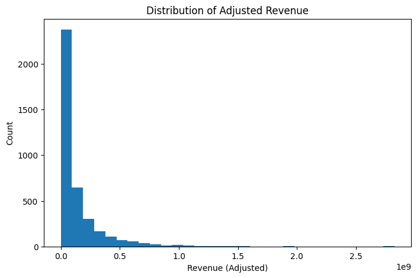

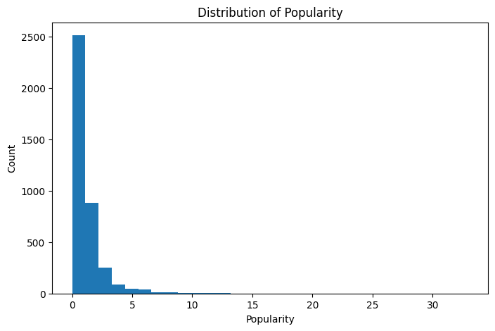

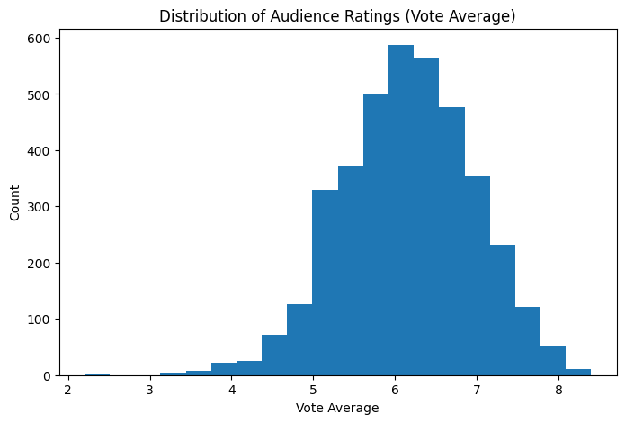

```python
# 1D Explorations: distributions of key variables
plt.figure(figsize=(8,5))
df['revenue_adj'].plot(kind='hist', bins=30)
style_plot('Distribution of Adjusted Revenue', 'Revenue (Adjusted)', 'Count')
plt.show()

plt.figure(figsize=(8,5))
df['popularity'].plot(kind='hist', bins=30)
style_plot('Distribution of Popularity', 'Popularity', 'Count')
plt.show()

plt.figure(figsize=(8,5))
df['vote_average'].plot(kind='hist', bins=20)
style_plot('Distribution of Audience Ratings (Vote Average)', 'Vote Average', 'Count')
plt.show()
```

## Exploratory Data Analysis

### Research Question 1: Is there a relationship between movie budget and revenue?

This question investigates whether movies with higher production budgets tend to generate higher revenues. Budget is considered one of the most important factors that may influence movie success, and analyzing this relationship may reveal whether larger investments lead to higher financial returns.

```python
# Select relevant columns and remove missing values
budget_revenue_df = df[['budget_adj', 'revenue_adj']].dropna()

# Summary statistics
budget_revenue_df.describe()
```

|  | budget_adj | revenue_adj |
| --- | --- | --- |
| count | 3.854000e+03 | 3.854000e+03 |
| mean | 4.423999e+07 | 1.370647e+08 |
| std | 4.480925e+07 | 2.161114e+08 |
| min | 9.693980e-01 | 2.370705e+00 |
| 25% | 1.309053e+07 | 1.835735e+07 |
| 50% | 3.001611e+07 | 6.173068e+07 |
| 75% | 6.061307e+07 | 1.632577e+08 |
| max | 4.250000e+08 | 2.827124e+09 |

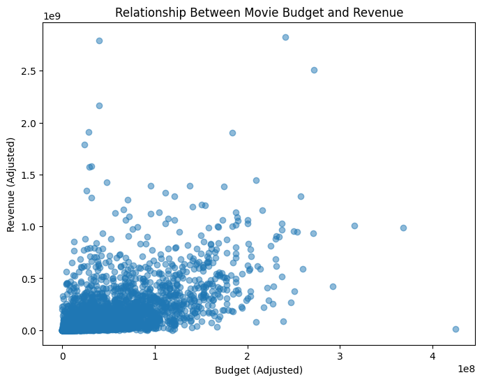

```python
# Scatter plot
plt.figure(figsize=(8,6))
plt.scatter(budget_revenue_df['budget_adj'], budget_revenue_df['revenue_adj'], alpha=0.5)
style_plot('Relationship Between Movie Budget and Revenue', 'Budget (Adjusted)', 'Revenue (Adjusted)')
plt.show()
```

```python
# Correlation
budget_revenue_df.corr()
```

|  | budget_adj | revenue_adj |
| --- | --- | --- |
| budget_adj | 1.000000 | 0.570451 |
| revenue_adj | 0.570451 | 1.000000 |

The scatter plot shows an positive relationship between movie budget and revenue. Movies with higher production budgets tend to generate higher revenues.

The correlation coefficient between adjusted budget and adjusted revenue is approximately 0.57, which indicates a moderate positive relationship between the two variables. This suggests that increasing the movie production budget is often associated with higher revenue, although budget alone does not fully determine movie success, as other factors may also influence financial performance.

### Research Question 2: Do certain movie genres generate higher revenue than others?

This question explores whether certain movie genres tend to generate higher revenues than others. Understanding which genres perform better financially can provide insights into audience preferences and industry trends.

To answer this question, movies will be grouped by their primary genre, and the average adjusted revenue for each genre will be calculated and visualized.

```python
# Calculate average revenue by genre
genre_revenue = df.groupby('primary_genre')['revenue_adj'].mean().sort_values(ascending=False)

# Display top genres
genre_revenue.head(10)
```

```
primary_genre
Adventure          3.041586e+08
Animation          2.959841e+08
Family             2.728411e+08
Science Fiction    2.171706e+08
Fantasy            1.943293e+08
History            1.680665e+08
Action             1.626525e+08
War                1.405774e+08
Music              1.285718e+08
Romance            1.242896e+08
Name: revenue_adj, dtype: float64
```

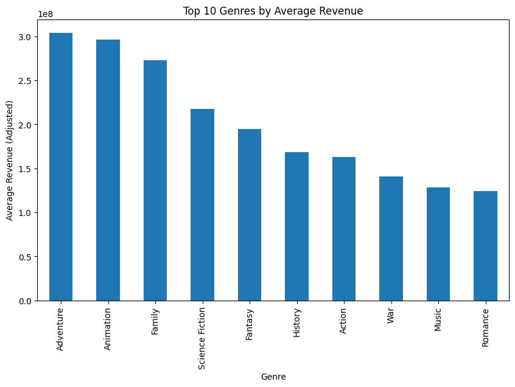

```python
# Bar plot visualization
plt.figure(figsize=(10,6))
genre_revenue.head(10).plot(kind='bar')
style_plot('Top 10 Genres by Average Revenue', 'Genre', 'Average Revenue (Adjusted)')
plt.show()
```

From the results, it is evident that the revenues generated from the respective movies vary depending on the genres of the movies. From the results, it is evident that Adventure movies performed best, followed by Animation and Family movies. They could be grand presentations, and the audiences they attracted could have led to the economic success of the movies.

From the analysis of all these, it is very clear that genre is one among those factors that affect the performance in terms of revenue, though there might be numerous factors acting as well.

### Research Question 3: Does movie popularity influence revenue?

This question explores the relationship that may exist between movie popularity and revenues. In particular, popularity has the potential to affect the movie's financial success.

In order to explore the nature of this relationship, the statistical summaries of the association between the adjusted revenues and popularity ratings for the movies can be examined.

```python
# Select relevant columns and remove missing values
popularity_revenue_df = df[['popularity', 'revenue_adj']].dropna()

# Summary statistics
popularity_revenue_df.describe()
```

|  | popularity | revenue_adj |
| --- | --- | --- |
| count | 3854.000000 | 3.854000e+03 |
| mean | 1.191554 | 1.370647e+08 |
| std | 1.475162 | 2.161114e+08 |
| min | 0.001117 | 2.370705e+00 |
| 25% | 0.462367 | 1.835735e+07 |
| 50% | 0.797511 | 6.173068e+07 |
| 75% | 1.368324 | 1.632577e+08 |
| max | 32.985763 | 2.827124e+09 |

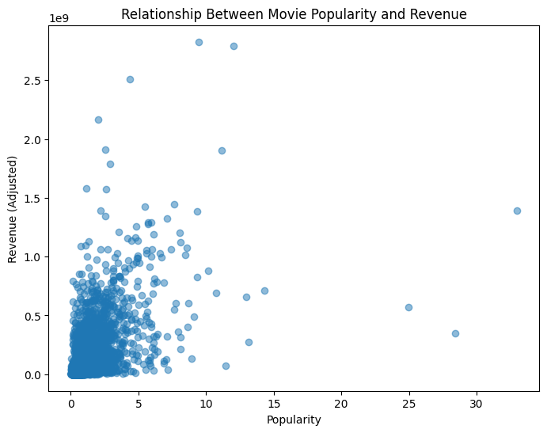

|  | popularity | revenue_adj |
| --- | --- | --- |
| popularity | 1.000000 | 0.546959 |
| revenue_adj | 0.546959 | 1.000000 |

```python
# Scatter plot
plt.figure(figsize=(8,6))
plt.scatter(popularity_revenue_df['popularity'], popularity_revenue_df['revenue_adj'], alpha=0.5)
style_plot('Relationship Between Movie Popularity and Revenue', 'Popularity', 'Revenue (Adjusted)')
plt.show()


# Correlation
popularity_revenue_df.corr()
```

From the scatter plot, the positive association between movie popularity and movie revenue is observed, showing that movies with higher popularity ratings also receive higher revenues.

The correlation coefficient for the relationship between popularity and adjusted revenue is approximately 0.55. It can be seen that it is a moderate positive relationship. It implies that movies that draw more audience interest or involvement show positive results.

### Research Question 4: Is there a relationship between audience ratings and movie revenue?

This is a question of whether audience ratings have any association with revenue generated by a movie. Ratings produced by the audience represent the satisfaction of the audience and the quality of the movie. A better-rated movie may attract a higher audience, leading to increased revenue.

In order to understand this, the statistical summary of the average audience rating (vote_average) with respect to adjusted revenue will be utilized.

```python
# Select relevant columns and remove missing values
rating_revenue_df = df[['vote_average', 'revenue_adj']].dropna()

# Summary statistics
rating_revenue_df.describe()
```

|  | vote_average | revenue_adj |
| --- | --- | --- |
| count | 3854.000000 | 3.854000e+03 |
| mean | 6.168163 | 1.370647e+08 |
| std | 0.794920 | 2.161114e+08 |
| min | 2.200000 | 2.370705e+00 |
| 25% | 5.700000 | 1.835735e+07 |
| 50% | 6.200000 | 6.173068e+07 |
| 75% | 6.700000 | 1.632577e+08 |
| max | 8.400000 | 2.827124e+09 |

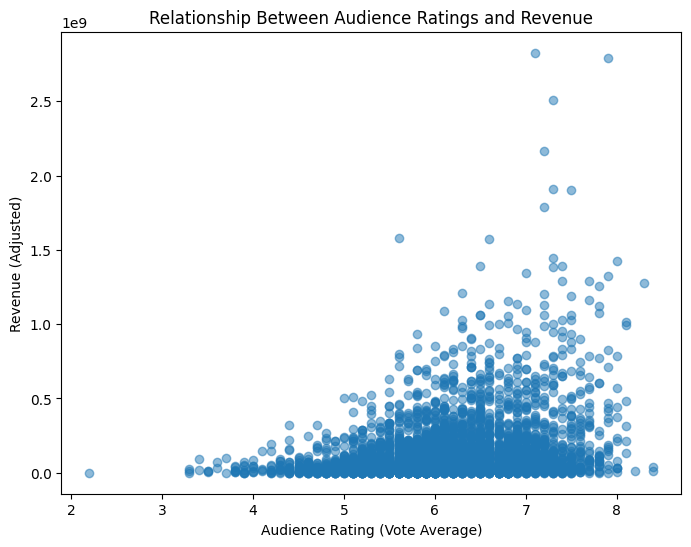

|  | vote_average | revenue_adj |
| --- | --- | --- |
| vote_average | 1.000000 | 0.266844 |
| revenue_adj | 0.266844 | 1.000000 |

```python
# Scatter plot
plt.figure(figsize=(8,6))
plt.scatter(rating_revenue_df['vote_average'], rating_revenue_df['revenue_adj'], alpha=0.5)
style_plot('Relationship Between Audience Ratings and Revenue', 'Audience Rating (Vote Average)', 'Revenue (Adjusted)')
plt.show()

# Correlation
rating_revenue_df.corr()
```

Based on the scatter plot provided, there is a weak positive relationship between audience ratings and revenue. Movies with high audience ratings seem to make a slightly higher revenue, although it is still not substantial.

The correlation coefficient between audience ratings and adjusted revenue is roughly 0.27, meaning the two have a weak positive relationship. This implies that, while audience ratings may have a positive impact on revenue, they have a weak impact on it.

These findings suggest that other factors, such as the production budget, genre, and popularity, may be more important when determining the financial success of a film.

## Conclusions

This analysis considered various factors that could potentially affect the revenue generated from movies, using the TMDb Movies dataset.

These results show that the production budget has a moderately positive association with the revenues, since the correlation is approximately 0.57. This means that movies with larger financial investments are apt to generate higher revenues.

Movie popularity was also moderately positively related to revenue, with a correlation of approximately 0.55. A movie that receives more audience attention and interest is very likely to result in better box office performance.

The genre analysis, meanwhile, showed the highest returns for Adventure, Animation, and Family movies. It could also be interpreted that such genres cater to the mass population and yield better economic returns.

In contrast, audience ratings were only weakly, albeit positively, correlated with revenue (correlation ≈ 0.27). While it is possible that more highly rated films have increased revenue, such factors cannot be used to strongly predict success.

Overall, the results suggest that the role of financial investment and audience popularity is more significant than that of audience ratings.

However, it is also important to note that this is exploratory analysis based on correlations. Therefore, we cannot say for sure that higher budgets or popularity actually lead to higher revenue. There could be other determinants of success, such as marketing, competition, distribution, international market, etc., which contribute to the overall business.

## Limitations

There are, however, a few limitations with this analysis. One of these limitations is that many rows were deleted during cleaning, which decreased the overall number of rows. Again, there are limitations with utilizing less data, which can create an inability to generalize. A second limitation involves the fact that there were no marketing expenses, audience demographics, or international performance provided by the dataset. A third limitation involves the fact that no statistical tests were conducted.

Further research could take into account additional variables, possibly using more advanced statistical models to ascertain what makes movies successful.

```python
# Running this cell will execute a bash command to convert this notebook to an .html file
!python -m nbconvert --to html Investigate_a_Dataset.ipynb
```

```
[NbConvertApp] Converting notebook Investigate_a_Dataset.ipynb to html
[NbConvertApp] WARNING | Alternative text is missing on 7 image(s).
[NbConvertApp] Writing 739008 bytes to Investigate_a_Dataset.html
```